## Homework 1

#### Knowledge and Visual Analytics

##### CUNY MSDS DATA 608, Fall 2018

### Rose Koh

##### 09/03/2018

### Intro

**Principles of Data Visualization and Introduction to ggplot2**

I have provided you with data about the 5,000 fastest growing companies in the US, as compiled by Inc. magazine. lets read this in:

```r
inc <- read.csv("https://raw.githubusercontent.com/charleyferrari/CUNY_DATA_608/master/module1/Data/inc5000_data.csv", header= TRUE)
```

And lets preview this data:

```r
head(inc)
```

```
##   Rank                         Name Growth_Rate   Revenue
## 1    1                         Fuhu      421.48 1.179e+08
## 2    2        FederalConference.com      248.31 4.960e+07
## 3    3                The HCI Group      245.45 2.550e+07
## 4    4                      Bridger      233.08 1.900e+09
## 5    5                       DataXu      213.37 8.700e+07
## 6    6 MileStone Community Builders      179.38 4.570e+07
##                       Industry Employees         City State
## 1 Consumer Products & Services       104   El Segundo    CA
## 2          Government Services        51     Dumfries    VA
## 3                       Health       132 Jacksonville    FL
## 4                       Energy        50      Addison    TX
## 5      Advertising & Marketing       220       Boston    MA
## 6                  Real Estate        63       Austin    TX
```

```r
summary(inc)
```

```
##       Rank                          Name       Growth_Rate
##  Min.   :   1   (Add)ventures         :   1   Min.   :  0.340
##  1st Qu.:1252   @Properties           :   1   1st Qu.:  0.770
##  Median :2502   1-Stop Translation USA:   1   Median :  1.420
##  Mean   :2502   110 Consulting        :   1   Mean   :  4.612
##  3rd Qu.:3751   11thStreetCoffee.com  :   1   3rd Qu.:  3.290
##  Max.   :5000   123 Exteriors         :   1   Max.   :421.480
##                 (Other)               :4995
##     Revenue                                  Industry      Employees
##  Min.   :2.000e+06   IT Services                 : 733   Min.   :    1.0
##  1st Qu.:5.100e+06   Business Products & Services: 482   1st Qu.:   25.0
##  Median :1.090e+07   Advertising & Marketing     : 471   Median :   53.0
##  Mean   :4.822e+07   Health                      : 355   Mean   :  232.7
##  3rd Qu.:2.860e+07   Software                    : 342   3rd Qu.:  132.0
##  Max.   :1.010e+10   Financial Services          : 260   Max.   :66803.0
##                      (Other)                     :2358   NA's   :12
##             City          State
##  New York     : 160   CA     : 701
##  Chicago      :  90   TX     : 387
##  Austin       :  88   NY     : 311
##  Houston      :  76   VA     : 283
##  San Francisco:  75   FL     : 282
##  Atlanta      :  74   IL     : 273
##  (Other)      :4438   (Other):2764
```

Think a bit on what these summaries mean. Use the space below to add some more relevant non-visual exploratory information you think helps you understand this data:

### Non-Visual EDA

```r
inc <- as.data.table(inc)

# list rows of data that have missing values
inc[!complete.cases(inc),]
```

```
##     Rank                             Name Growth_Rate   Revenue
##  1:  183           First Flight Solutions       22.32   2700000
##  2: 1064                         Popchips        3.98  93300000
##  3: 1124                       Vocalocity        3.72  42900000
##  4: 1653                     Higher Logic        2.36   6000000
##  5: 1686      Global Communications Group        2.30   3600000
##  6: 2197              JeffreyM Consulting        1.68  12100000
##  7: 2743               Excalibur Exhibits        1.27   9900000
##  8: 3001       Heartland Business Systems        1.12 156300000
##  9: 3978                             SSEC        0.68  80400000
## 10: 4112 Carolinas Home Medical Equipment        0.64   3300000
## 11: 4566                         Oakbrook        0.48   8900000
## 12: 4968                   Popcorn Palace        0.35   5500000
##                         Industry Employees          City State
##  1:   Logistics & Transportation        NA  Emerald Isle    NC
##  2:              Food & Beverage        NA San Francisco    CA
##  3:           Telecommunications        NA       Atlanta    GA
##  4:                     Software        NA    Washington    DC
##  5:           Telecommunications        NA     Englewood    CO
##  6: Business Products & Services        NA      Bellevue    WA
##  7: Business Products & Services        NA       houston    TX
##  8:                  IT Services        NA  Little Chute    WI
##  9:                Manufacturing        NA       Horsham    PA
## 10:                       Health        NA      Matthews    NC
## 11:                  Real Estate        NA       Madison    WI
## 12:              Food & Beverage        NA Schiller Park    IL
```

```r
new.inc <- na.omit(inc)

# growth rate summary by indsutry
head(arrange(new.inc[, .(mean_growth_rate = mean(Growth_Rate),
                median_growth_rate = median(Growth_Rate),
                min_growth_rate = min(Growth_Rate),
                max_growth_rate = max(Growth_Rate)), by = .(Industry)], desc(mean_growth_rate)),10)
```

```
##                        Industry mean_growth_rate median_growth_rate
## 1                        Energy         9.603303              2.080
## 2  Consumer Products & Services         8.776108              1.820
## 3                   Real Estate         7.823158              2.080
## 4           Government Services         7.238168              2.110
## 5       Advertising & Marketing         6.225478              1.610
## 6                        Retail         6.184729              1.760
## 7            Financial Services         5.435308              1.485
## 8                      Software         5.028446              1.700
## 9                        Health         4.868305              1.570
## 10                        Media         4.374074              1.940
##    min_growth_rate max_growth_rate
## 1             0.35          233.08
## 2             0.35          421.48
## 3             0.35          179.38
## 4             0.35          248.31
## 5             0.35          213.37
## 6             0.34          166.89
## 7             0.34          174.04
## 8             0.35          128.63
## 9             0.35          245.45
## 10            0.41           23.01
```

```r
# revenue summary by industry
head(arrange(new.inc[, .(mean_rev = mean(Revenue),
            median_rev = median(Revenue),
            min_rev = min(Revenue),
            max_rev = max(Revenue)), by = .(Industry)], desc(mean_rev)),10)
```

```
##                        Industry  mean_rev median_rev min_rev   max_rev
## 1             Computer Hardware 270129545   22350000 3800000 1.010e+10
## 2                        Energy 126344954   29400000 2100000 1.900e+09
## 3               Food & Beverage  99321705   18600000 2000000 4.500e+09
## 4    Logistics & Transportation  96349351   20800000 2300000 1.900e+09
## 5  Consumer Products & Services  73676847    9400000 2000000 4.600e+09
## 6                  Construction  70450802   14000000 2100000 4.700e+09
## 7            Telecommunications  57385039   16600000 2100000 8.462e+08
## 8  Business Products & Services  54887292    9750000 2000000 2.400e+09
## 9                      Security  52230137   12300000 2000000 7.181e+08
## 10       Environmental Services  51741176   12500000 2100000 1.400e+09
```

```r
# number of employees by industry
head(arrange(new.inc[, .(sum_employee = sum(Employees),
                    mean_employee = mean(Employees),
                    min_employee = min(Employees),
                    max_employee = max(Employees)), by =.(Industry)], desc(sum_employee)),10)
```

```
##                        Industry sum_employee mean_employee min_employee
## 1               Human Resources       226980     1158.0612            4
## 2  Business Products & Services       117357      244.4938            4
## 3                   IT Services       102788      140.4208            2
## 4                        Health        82430      232.8531            2
## 5               Food & Beverage        65911      510.9380            3
## 6                      Software        51262      150.3284            1
## 7            Financial Services        47693      183.4346            5
## 8  Consumer Products & Services        45464      223.9606            1
## 9                 Manufacturing        43942      172.3216            1
## 10                     Security        41059      562.4521            7
##    max_employee
## 1         66803
## 2         32000
## 3          7000
## 4          4390
## 5          7681
## 6          3000
## 7          1829
## 8         13200
## 9          8500
## 10        20000
```

```r
# number of cities by industry
head(arrange(new.inc[, .(count = length(unique(City))), by =.(Industry)], desc(count)),10)
```

```
##                        Industry count
## 1                   IT Services   388
## 2  Business Products & Services   292
## 3                        Health   257
## 4       Advertising & Marketing   252
## 5                 Manufacturing   223
## 6                      Software   202
## 7            Financial Services   191
## 8                        Retail   164
## 9                  Construction   157
## 10 Consumer Products & Services   152
```

```r
# number of state by industry
head(arrange(new.inc[, .(count = length(unique(State))), by =.(Industry)], desc(count)),10)
```

```
##                        Industry count
## 1                        Health    44
## 2                      Software    44
## 3                   IT Services    44
## 4       Advertising & Marketing    43
## 5  Business Products & Services    42
## 6            Financial Services    39
## 7                 Manufacturing    38
## 8                        Retail    37
## 9                  Construction    36
## 10 Consumer Products & Services    34
```

```r
# number of cities by state
head(arrange(new.inc[, .(count = length(unique(City))), by =.(State)], desc(count)),10)
```

```
##    State count
## 1     CA   204
## 2     IL   104
## 3     FL   102
## 4     NJ    97
## 5     NY    90
## 6     PA    80
## 7     OH    79
## 8     MA    72
## 9     TX    66
## 10    VA    56
```

```r
# number of companies by industry
head(arrange(new.inc[, .(count = length(unique(Name))), by = .(Industry)], desc(count)),10)
```

```
##                        Industry count
## 1                   IT Services   732
## 2  Business Products & Services   480
## 3       Advertising & Marketing   471
## 4                        Health   354
## 5                      Software   341
## 6            Financial Services   260
## 7                 Manufacturing   255
## 8  Consumer Products & Services   203
## 9                        Retail   203
## 10          Government Services   202
```

```r
# number of companies by cities
head(arrange(new.inc[, .(count = length(unique(Name))), by = .(City)], desc(count)),10)
```

```
##             City count
## 1       New York   160
## 2        Chicago    90
## 3         Austin    88
## 4        Houston    76
## 5  San Francisco    74
## 6        Atlanta    73
## 7      San Diego    67
## 8        Seattle    52
## 9         Boston    43
## 10        Denver    42
```

```r
# number of companies by state
head(arrange(new.inc[, .(count = length(unique(Name))), by = .(State)], desc(count)),10)
```

```
##    State count
## 1     CA   700
## 2     TX   386
## 3     NY   311
## 4     VA   283
## 5     FL   282
## 6     IL   272
## 7     GA   211
## 8     OH   186
## 9     MA   182
## 10    PA   163
```

### Question 1

Create a graph that shows the distribution of companies in the dataset by State (ie how many are in each state). There are a lot of States, so consider which axis you should use. This visualization is ultimately going to be consumed on a ‘portrait’ oriented screen (ie taller than wide), which should further guide your layout choices.

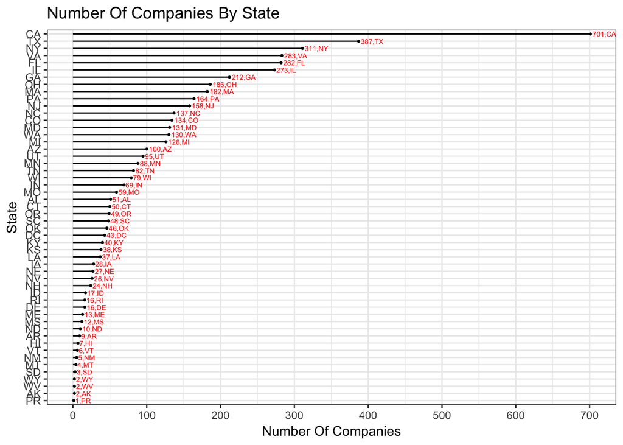

```r
data.1 <- arrange(inc[, .(num_of_companies = length(Name)), by =.(State)], desc(num_of_companies))

plot1 <- ggplot(data.1,
                aes(reorder(State, num_of_companies), num_of_companies)) +
  geom_point(size=0.5) +
  geom_segment(aes(x=State, xend=State, y=0, yend=num_of_companies)) +
  geom_text(aes(label = paste0(num_of_companies, ",", State)),
                  color = "red", size = 2, hjust = -0.1)+
  scale_y_continuous(breaks = seq(0,800,100),labels = comma) +
  labs(title = "Number Of Companies By State",
       x = "State",
       y = "Number Of Companies") +
  coord_flip() +
  theme_bw()

plot1
```

### Quesiton 2

Lets dig in on the state with the 3rd most companies in the data set. Imagine you work for the state and are interested in how many people are employed by companies in different industries. Create a plot that shows the average and/or median employment by industry for companies in this state (only use cases with full data, use R’s `complete.cases()` function.) In addition to this, your graph should show how variable the ranges are, and you should deal with outliers.

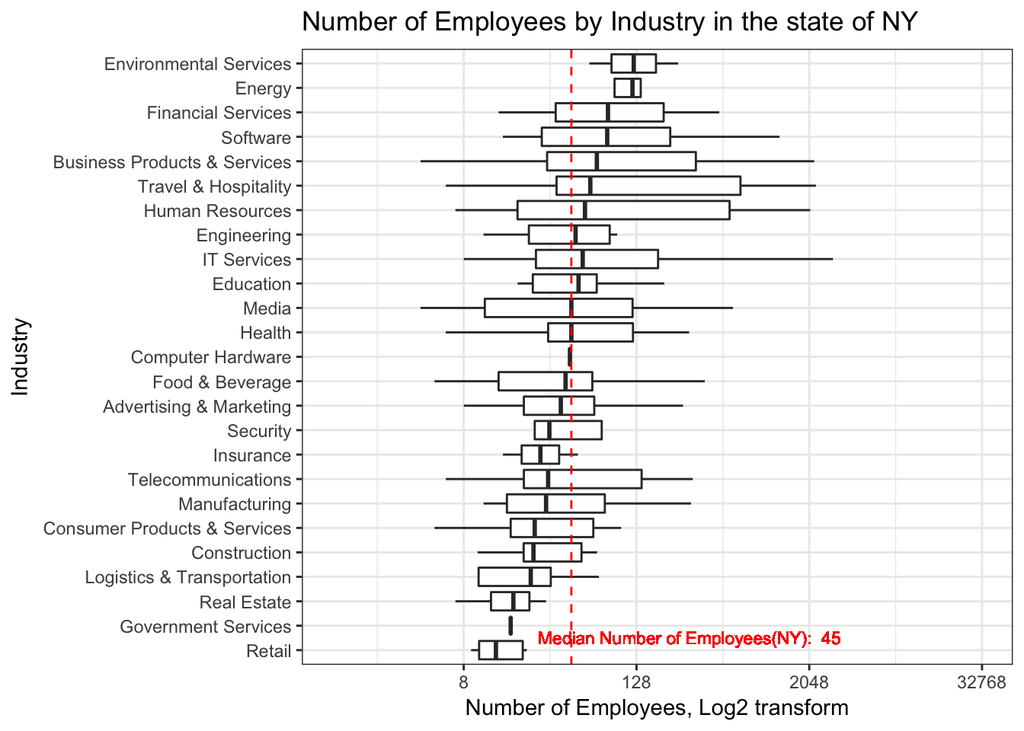

```r
#head(arrange(new.inc[, .(count = length(unique(Name))), by = .(State)], desc(count)),3)

data.2 <- inc[complete.cases(inc),][State == 'NY']

upper <- max(data.2$Employees)
lower <- min(data.2$Employees)
median.label <- paste0("Median Number of Employees(NY):  ", median(data.2$Employees))

plot2 <- ggplot(data.2,aes(reorder(Industry, Employees, FUN=median), Employees)) +
  geom_boxplot(outlier.shape = NA) +
  geom_hline(yintercept = median(data.2$Employees),
               color="red",
               linetype="dashed") +
  scale_y_continuous(trans = log2_trans(), limits = c(lower, upper)) +
  labs(title = "Number of Employees by Industry in the state of NY",
     x = "Industry",
     y = "Number of Employees, Log2 transform") +
  geom_text(aes(x=1.5, label=median.label, y = 300),
            size = 3,
            colour="red") +
  theme_bw() +
  coord_flip()

plot2
```

### Question 3

Now imagine you work for an investor and want to see which industries generate the most revenue per employee. Create a chart that makes this information clear. Once again, the distribution per industry should be shown.

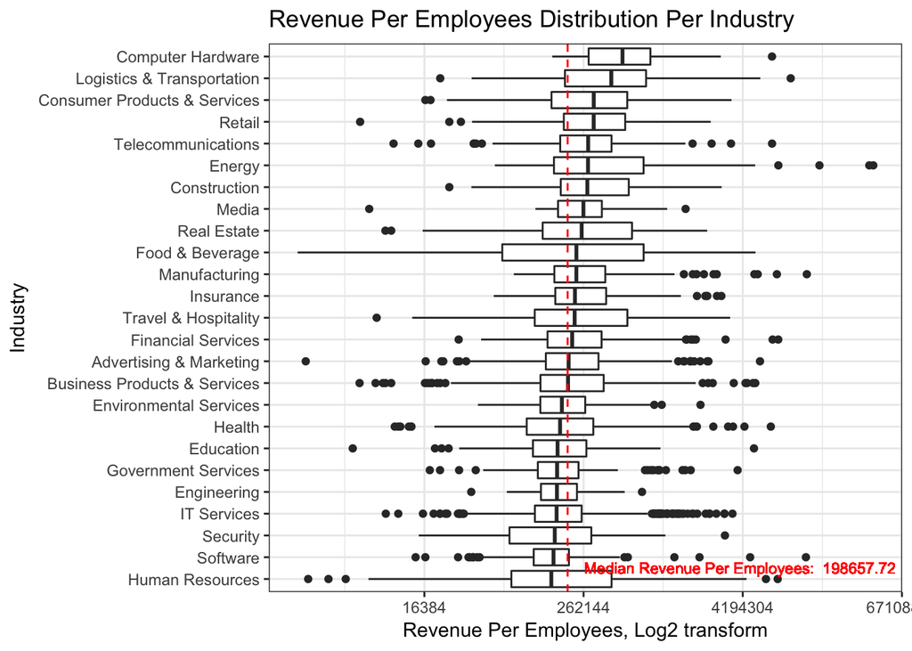

```r
data.3 <- arrange(inc[complete.cases(inc),][, `:=`(RPE = Revenue/Employees)], desc(RPE))

upper <- max(data.3$RPE)
lower <- min(data.3$RPE)
median.label <- paste0("Median Revenue Per Employees:  ", round(median(data.3$RPE),2))

plot3 <- ggplot(data.3, aes(reorder(Industry, RPE, FUN=median), RPE)) +
  geom_boxplot() +
  geom_hline(yintercept = median(data.3$RPE),
               color="red",
               linetype="dashed") +
  scale_y_continuous(trans = log2_trans(), limits = c(lower, upper)) +
  labs(title = "Revenue Per Employees Distribution Per Industry",
     x = "Industry",
     y = "Revenue Per Employees, Log2 transform") +
  geom_text(aes(x=1.5, label=median.label, y = 4000000),
            size = 3,
            colour="red") +
  theme_bw() +
  coord_flip()

plot3
```